# Root traits operator bias: method, results and correction

## For data users

Root measurements from 2022 root ingrowth cores (RIC) were washed, weighed in the lab and the root traits were then processed with a root-scanning software by several operators. Different operators worked on different treatment plots, and exploratory analyses showed systematic differences between operators that were often larger than differences among experimental treatments or sites. Uncorrected values can therefore confound ecological interpretation. Root biomass from 2021 (`root_biomass`, standing biomass from soil cores in g/m³ using RIC core volume) is not corrected because that dataset was not measured by different operators.

We applied an operator-bias correction to the 2022 data in the cleaning pipeline (`R/root_plan.R`). One operator was chosen as the reference because they had measured all treatments in at least one block, giving overlap with every other operator on shared treatments. For each non-reference operator, treatment-specific offsets relative to the reference were estimated using only plots where both operators had measured the same treatments. The model was `trait ~ siteID * treatment + treatment:operator`; each corrected value is raw minus the predicted operator offset for that site, treatment, and operator (reference-operator values are unchanged).

In the exported long-format file `FUNDER_clean_root_biomass_productivity_traits_2021-2022.csv`, raw values are in `value` and corrected values in `value_corrected`. You may use either column depending on your analysis; **we recommend `value_corrected` for 2022 RIC traits** when comparing treatments or sites. Implementation: `apply_operator_correction()` in `R/functions/correct_operator_bias.R`.

This document describes the problem, diagnostics, and correction in detail (operator identities are anonymized here; the clean dataset retains the original `operator` field). A pre-rendered HTML version is published at between-the-fjords.github.io/funder_data/operator_bias.html (enable GitHub Pages from the `docs/` folder on the repository). Source: `FUNDER-RIC_root_traits_operator_bias.qmd`.

## Aim

Root trait data (`root_traits_clean`) are produced by several operators (winRhIZO scans and manual measurements). When plotting traits by operator, operator differences can be larger than treatment or site differences, which can obscure ecological effects. This document (1) quantifies how much variance is due to operator vs site and treatment, (2) shows where the bias appears, and (3) applies a correction so downstream analyses can use operator-adjusted values.

## Method

**Variance decomposition.** For each trait we fit three linear models:

- *Operator only:* `trait ~ operator` — how much variance operator explains alone.
- *Site × treatment:* `trait ~ siteID * treatment` — site, treatment, and their interaction (treatment nested within site).
- *Full:* `trait ~ siteID * treatment + operator` — site × treatment plus additive operator (operator is not nested in site/treatment).

We report R² for each model and the **partial R² for operator** (increase in R² when adding operator to site × treatment). If partial R² for operator is large, operator bias is substantial relative to ecological structure.

**Operator effects.** From the full model we report the estimated effect of each operator relative to a reference level (Operator A). These are the systematic offsets we will remove in the correction.

**Correction (subset-based approach, treatment × operator interaction).** We estimate each operator’s effect **only from treatments where both that operator and the reference measured**. This avoids extrapolation and confounding between operator and treatment. For the reference operator, values are unchanged. For each other operator, we fit `trait ~ siteID * treatment + treatment:operator` on the shared-treatment subset. The correction subtracts the **treatment-specific** operator offset for each row (predicted value with that operator minus predicted value if the reference operator had measured the same plot). Corrected values are stored as `value_corrected` in the long export (`value` = raw); in wide tables the same values appear in `<trait>_corrected` columns. Rows without operator get `NA`. Implemented in `apply_operator_correction()` in `R/functions/correct_operator_bias.R` (`operator_model = "interaction"`).

**How the correction is calculated (detail).**

1. **Choose the reference operator.** The reference had the most complete coverage across treatments within a block. Their values are left uncorrected (Operator A in this report).
2. **For each other operator:** Find treatments where both that operator and the reference have non-missing trait values. Subset the data to those treatments and those two operators only.
3. **Fit the model on the subset.** Fit `trait ~ siteID * treatment + treatment:operator` with reference operator as baseline. Operator offsets can therefore differ by treatment.
4. **Apply correction.** For each row measured by that operator: corrected = raw − (predicted with actual operator − predicted with reference operator), holding site and treatment fixed. For the reference operator’s rows: corrected = raw.
5. **Store.** Corrected values go to `value_corrected` in the long CSV (or `<trait>_corrected` in wide format). Operators with insufficient overlap (e.g. fewer than 5 rows in shared treatments) get `NA`.

## Data

We use `root_traits_clean` from the root targets pipeline (`R/root_plan.R`). This document analyses 2022 RIC ingrowth traits. Operator comes from the RIC lab workflow (`clean_root_lab_data()`): who processed each ingrowth core.

`dry_root_turnover_g` is dry mass of roots that grew into ingrowth cores between burial and retrieval (2022). `root_productivity_g_per_m3_per_year` = `dry_root_turnover_g / ric_volume_m3 / duration_years`.

Operator-bias correction applies to these RIC traits; corrected values are in `value_corrected` in the pipeline output.

**Analysis subset.** 381 plots with RIC measurements and operator (four operators, labelled A–D below). Two plots in `root_traits_clean` have no RIC data and no operator (`Fau2GB`, `Ulv1B`); they are dropped.

```r
suppressPackageStartupMessages(library(tidyverse))

# Load wide root traits table from pipeline (run tar_make() first)
if (!exists("root_traits_clean")) {
  if (requireNamespace("targets", quietly = TRUE)) {
    root_traits_clean <- targets::tar_read("root_traits_clean")
    if (targets::tar_exist_objects("root_traits_corrected")) {
      root_traits_corrected <- targets::tar_read("root_traits_corrected")
    }
  } else {
    stop("root_traits_clean not found. Run targets::tar_make() in this project first.")
  }
}

TRAIT_COLS <- c(
  "dry_root_turnover_g",
  "root_length_m",
  "avg_root_diameter_m",
  "specific_root_length_m_per_g",
  "root_tissue_density_g_per_m3",
  "root_dry_matter_content",
  "root_productivity_g_per_m3_per_year"
)
# Display names for tables and figures
TRAIT_LABELS <- c(
  dry_root_turnover_g = "RIC root turnover (g, 2022)",
  root_length_m = "Root length (m)",
  avg_root_diameter_m = "Average root diameter (m)",
  specific_root_length_m_per_g = "Specific root length (m/g)",
  root_tissue_density_g_per_m3 = "Root tissue density (g/m³)",
  root_dry_matter_content = "Root dry matter content",
  root_productivity_g_per_m3_per_year = "Root productivity (g/m³/year)"
)

op_col <- intersect(c("operator", "Operator"), names(root_traits_clean))[1]
if (is.na(op_col)) stop("No operator/Operator column in root_traits_clean.")
if (op_col == "Operator") root_traits_clean$operator <- root_traits_clean$Operator

dat <- root_traits_clean %>%
  filter(!is.na(operator)) %>%
  mutate(
    treatment = factor(treatment, levels = c("C", "G", "F", "B", "FB", "GB", "GF", "FGB")),
    operator = factor(operator)
  )

run_operator_analysis <- nlevels(dat$operator) >= 2L
# Reference operator (real name in data; anonymised label Operator A in this report)
ref_operator <- if (run_operator_analysis) {
  if ("Michaela" %in% levels(dat$operator)) "Michaela" else levels(dat$operator)[1]
} else NA_character_

operator_anon_labels <- function(operators, reference) {
  labels <- setNames(character(length(operators)), operators)
  labels[[reference]] <- "Operator A"
  others <- sort(setdiff(operators, reference))
  for (i in seq_along(others)) {
    labels[[others[i]]] <- paste0("Operator ", LETTERS[i + 1L])
  }
  labels
}

OPERATOR_ANON <- if (run_operator_analysis) {
  operator_anon_labels(levels(dat$operator), ref_operator)
} else character(0)

operator_display <- function(x) {
  unname(OPERATOR_ANON[as.character(x)])
}

# Set reference level so model coefficients are "effect vs reference"
dat <- dat %>%
  mutate(
    operator = relevel(operator, ref = ref_operator),
    operator_label = factor(
      operator_display(operator),
      levels = unname(OPERATOR_ANON[levels(operator)])
    )
  )
```

## Results

### Operator sample sizes and coverage

```r
operator_summary <- dat %>%
  count(operator_label, name = "n_plots") %>%
  rename(operator = operator_label)

operator_by_site <- dat %>%
  count(operator_label, siteID) %>%
  pivot_wider(names_from = operator_label, values_from = n, values_fill = 0)

operator_by_treatment <- dat %>%
  count(operator_label, treatment, .drop = FALSE) %>%
  pivot_wider(names_from = operator_label, values_from = n, values_fill = 0)

knitr::kable(operator_summary, caption = "Number of plots per operator.")
knitr::kable(operator_by_site, caption = "Operator × site (counts).")
knitr::kable(operator_by_treatment, caption = "Operator × treatment (counts).")
```

| operator | n_plots |
| --- | --- |
| Operator A | 94 |
| Operator B | 107 |
| Operator C | 108 |
| Operator D | 72 |

| siteID | Operator A | Operator B | Operator C | Operator D |
| --- | --- | --- | --- | --- |
| Alrust | 8 | 9 | 9 | 6 |
| Arhelleren | 8 | 8 | 10 | 6 |
| Fauske | 8 | 9 | 8 | 6 |
| Gudmedalen | 8 | 9 | 9 | 6 |
| Hogsete | 8 | 9 | 9 | 6 |
| Lavisdalen | 7 | 9 | 10 | 6 |
| Ovstedalen | 8 | 9 | 9 | 6 |
| Rambera | 8 | 9 | 9 | 6 |
| Skjelingahaugen | 7 | 10 | 8 | 6 |
| Ulvehaugen | 8 | 8 | 9 | 6 |
| Veskre | 8 | 9 | 9 | 6 |
| Vikesland | 8 | 9 | 9 | 6 |

| treatment | Operator A | Operator B | Operator C | Operator D |
| --- | --- | --- | --- | --- |
| C | 11 | 0 | 0 | 36 |
| G | 12 | 35 | 1 | 0 |
| F | 12 | 36 | 0 | 0 |
| B | 12 | 35 | 0 | 0 |
| FB | 12 | 0 | 36 | 0 |
| GB | 12 | 1 | 34 | 0 |
| GF | 11 | 0 | 37 | 0 |
| FGB | 12 | 0 | 0 | 36 |

### Variance decomposition (R²)

For each trait we compare how much variance is explained by operator alone, by site × treatment, and by the full model. The last column is the **partial R² for operator** (extra variance when adding operator to site × treatment).

```r
if (run_operator_analysis) {
  variance_decomp <- function(trait_name) {
    form_op   <- as.formula(paste(trait_name, "~ operator"))
    form_st   <- as.formula(paste(trait_name, "~ siteID * treatment"))
    form_full <- as.formula(paste(trait_name, "~ siteID * treatment + operator"))
    d <- dat %>% filter(!is.na(.data[[trait_name]]), is.finite(.data[[trait_name]]))
    if (nrow(d) < 10L) return(NULL)
    m_op   <- lm(form_op,   data = d)
    m_st   <- lm(form_st,   data = d)
    m_full <- lm(form_full, data = d)
    tibble(
      trait = trait_name,
      n = nrow(d),
      R2_operator_only = summary(m_op)$r.squared,
      R2_site_treatment = summary(m_st)$r.squared,
      R2_full = summary(m_full)$r.squared,
      R2_partial_operator = summary(m_full)$r.squared - summary(m_st)$r.squared
    )
  }
  var_table <- TRAIT_COLS %>%
    map_dfr(variance_decomp) %>%
    filter(!is.na(R2_full)) %>%
    mutate(
      trait = unname(TRAIT_LABELS[trait]),
      R2_partial_operator_pct = 100 * R2_partial_operator
    ) %>%
    select(trait, n, R2_operator_only, R2_site_treatment, R2_full, R2_partial_operator, R2_partial_operator_pct)
  knitr::kable(
    var_table %>% rename(
      Trait = trait,
      `R² operator only` = R2_operator_only,
      `R² site × treatment` = R2_site_treatment,
      `R² full` = R2_full,
      `Partial R² operator` = R2_partial_operator,
      `Partial R² operator (%)` = R2_partial_operator_pct
    ),
    digits = 3,
    caption = "Variance decomposition (R²). Models: site × treatment (nested); full = site × treatment + operator. Partial R² for operator = R2_full - R2_site_treatment; (%) = × 100."
  )
} else {
  var_table <- tibble()
  knitr::kable(tibble(message = "Only one operator level; variance decomposition skipped."))
}
```

Table 2: Variance decomposition (R²). Models: site × treatment (nested); full = site × treatment + operator. Partial R² for operator = R2_full - R2_site_treatment; (%) = × 100.

| Trait | n | R² operator only | R² site × treatment | R² full | Partial R² operator | Partial R² operator (%) |
| --- | --- | --- | --- | --- | --- | --- |
| RIC root turnover (g, 2022) | 381 | 0.318 | 0.383 | 0.594 | 0.211 | 21.117 |
| Root length (m) | 380 | 0.099 | 0.505 | 0.576 | 0.071 | 7.081 |
| Average root diameter (m) | 379 | 0.103 | 0.425 | 0.533 | 0.108 | 10.771 |
| Specific root length (m/g) | 380 | 0.322 | 0.376 | 0.607 | 0.232 | 23.172 |
| Root tissue density (g/m³) | 379 | 0.339 | 0.456 | 0.583 | 0.127 | 12.738 |
| Root dry matter content | 381 | 0.361 | 0.499 | 0.692 | 0.193 | 19.264 |
| Root productivity (g/m³/year) | 381 | 0.327 | 0.365 | 0.571 | 0.206 | 20.596 |

**Interpretation:** If `R2_partial_operator` is large for a trait, operator explains substantial variance beyond site and treatment, so correction is useful for that trait.

### Measurement consistency: reference operator variability across conditions

To assess whether the reference operator (Operator A) measures consistently, we examine measurement variability across treatments and sites. If the reference operator’s coefficient of variation (CV = SD/mean) is similar across conditions, they are a stable baseline.

**Reference operator variability by treatment:**

```r
if (run_operator_analysis && "dry_root_turnover_g" %in% names(dat)) {
  # Calculate summary statistics by operator and treatment
  operator_variability <- dat %>%
    filter(!is.na(dry_root_turnover_g)) %>%
    group_by(operator_label, treatment) %>%
    summarise(
      n = n(),
      mean = mean(dry_root_turnover_g),
      sd = sd(dry_root_turnover_g),
      cv = sd(dry_root_turnover_g) / mean(dry_root_turnover_g),
      .groups = "drop"
    ) %>%
    filter(n >= 3)  # Only show combinations with at least 3 observations

  ref_variability <- operator_variability %>%
    filter(operator_label == operator_display(ref_operator)) %>%
    select(treatment, n, mean, sd, cv)

  knitr::kable(
    ref_variability,
    digits = 3,
    caption = "Reference operator (Operator A) measurement variability by treatment for RIC root turnover."
  )
}
```

Table 3: Reference operator (Operator A) measurement variability by treatment for RIC root turnover.

| treatment | n | mean | sd | cv |
| --- | --- | --- | --- | --- |
| C | 11 | 0.062 | 0.031 | 0.497 |
| G | 12 | 0.047 | 0.018 | 0.379 |
| F | 12 | 0.062 | 0.036 | 0.584 |
| B | 12 | 0.064 | 0.027 | 0.416 |
| FB | 12 | 0.067 | 0.029 | 0.428 |
| GB | 12 | 0.044 | 0.024 | 0.533 |
| GF | 11 | 0.049 | 0.037 | 0.751 |
| FGB | 12 | 0.034 | 0.023 | 0.667 |

**Reference operator variability by site:**

```r
if (run_operator_analysis && "dry_root_turnover_g" %in% names(dat)) {
  # Same analysis by site
  operator_variability_site <- dat %>%
    filter(!is.na(dry_root_turnover_g)) %>%
    group_by(operator_label, siteID) %>%
    summarise(
      n = n(),
      mean = mean(dry_root_turnover_g),
      sd = sd(dry_root_turnover_g),
      cv = sd(dry_root_turnover_g) / mean(dry_root_turnover_g),
      .groups = "drop"
    ) %>%
    filter(n >= 3)

  ref_variability_site <- operator_variability_site %>%
    filter(operator_label == operator_display(ref_operator)) %>%
    select(siteID, n, mean, sd, cv)

  knitr::kable(
    ref_variability_site,
    digits = 3,
    caption = "Reference operator (Operator A) measurement variability by site for RIC root turnover. If CV is similar across sites, measurement consistency is good."
  )
}
```

Table 4: Reference operator (Operator A) measurement variability by site for RIC root turnover. If CV is similar across sites, measurement consistency is good.

| siteID | n | mean | sd | cv |
| --- | --- | --- | --- | --- |
| Alrust | 8 | 0.031 | 0.019 | 0.635 |
| Arhelleren | 8 | 0.059 | 0.031 | 0.520 |
| Fauske | 8 | 0.068 | 0.023 | 0.331 |
| Gudmedalen | 8 | 0.054 | 0.031 | 0.570 |
| Hogsete | 8 | 0.087 | 0.027 | 0.310 |
| Lavisdalen | 7 | 0.063 | 0.019 | 0.305 |
| Ovstedalen | 8 | 0.052 | 0.028 | 0.548 |
| Rambera | 8 | 0.032 | 0.016 | 0.514 |
| Skjelingahaugen | 7 | 0.066 | 0.034 | 0.515 |
| Ulvehaugen | 8 | 0.066 | 0.036 | 0.543 |
| Veskre | 8 | 0.043 | 0.012 | 0.279 |
| Vikesland | 8 | 0.025 | 0.010 | 0.403 |

### Testing for treatment × operator interaction (within subsets)

```r
if (run_operator_analysis && "dry_root_turnover_g" %in% names(dat)) {
  other_operators <- setdiff(levels(dat$operator), ref_operator)
  trait_test <- "dry_root_turnover_g"

  interaction_test_results <- tibble(
    operator_pair = character(),
    n = integer(),
    AIC_additive = numeric(),
    AIC_interaction = numeric(),
    delta_AIC = numeric(),
    interaction_better = logical()
  )

  for (op in other_operators) {
    op_treatments <- dat %>% filter(operator == op, !is.na(.data[[trait_test]])) %>% pull(treatment) %>% unique()
    ref_treatments <- dat %>% filter(operator == ref_operator, !is.na(.data[[trait_test]])) %>% pull(treatment) %>% unique()
    shared <- intersect(op_treatments, ref_treatments)
    if (length(shared) < 2) next  # Need at least 2 treatments to test interaction

    subset_data <- dat %>%
      filter(treatment %in% shared, operator %in% c(op, ref_operator), !is.na(.data[[trait_test]])) %>%
      mutate(operator = relevel(operator, ref = ref_operator))

    if (nrow(subset_data) < 10) next

    m_add <- tryCatch(lm(as.formula(paste(trait_test, "~ siteID * treatment + operator")), data = subset_data), error = function(e) NULL)
    m_int <- tryCatch(lm(as.formula(paste(trait_test, "~ siteID * treatment + treatment:operator")), data = subset_data), error = function(e) NULL)

    if (is.null(m_add) || is.null(m_int)) next

    aic_add <- AIC(m_add)
    aic_int <- AIC(m_int)
    delta <- aic_int - aic_add  # negative = interaction better

    interaction_test_results <- bind_rows(
      interaction_test_results,
      tibble(
        operator_pair = paste(operator_display(ref_operator), "vs", operator_display(op)),
        n = nrow(subset_data),
        AIC_additive = round(aic_add, 1),
        AIC_interaction = round(aic_int, 1),
        delta_AIC = round(delta, 1),
        interaction_better = delta < -2
      )
    )
  }

  knitr::kable(
    interaction_test_results %>% rename(
      `Operator pair` = operator_pair,
      N = n,
      `AIC (additive)` = AIC_additive,
      `AIC (interaction)` = AIC_interaction,
      `ΔAIC (int - add)` = delta_AIC,
      `Interaction better?` = interaction_better
    ),
    digits = 1,
    caption = "Treatment × operator interaction test within subsets. Each row: subset where both operators measured. ΔAIC < -2 means interaction model fits better; would suggest treatment-specific corrections."
  )
}
```

Table 5: Treatment × operator interaction test within subsets. Each row: subset where both operators measured. ΔAIC < -2 means interaction model fits better; would suggest treatment-specific corrections.

| Operator pair | N | AIC (additive) | AIC (interaction) | ΔAIC (int - add) | Interaction better? |
| --- | --- | --- | --- | --- | --- |
| Operator A vs Operator B | 155 | -552.7 | -549.1 | 3.6 | FALSE |
| Operator A vs Operator C | 155 | -404.5 | -403.7 | 0.8 | FALSE |
| Operator A vs Operator D | 95 | -347.7 | -345.8 | 1.9 | FALSE |

**Interpretation:** Compare ΔAIC across operator pairs. Where the interaction model fits better (ΔAIC < −2), operator offsets likely vary by treatment. **Correction below uses the interaction model** so each row is adjusted by its treatment-specific operator offset rather than a single average offset per operator.

### Operator effects (subset-based, vs reference)

Estimated effect of each operator relative to the reference (Operator A). Effects are estimated only from treatments where both that operator and the reference measured. Positive = higher trait value than reference on average. The reference operator does not appear (effect = 0 by definition).

```r
if (run_operator_analysis) {
  subset_operator_effects <- function(data, trait_name, reference_operator) {
    other_operators <- setdiff(levels(data$operator), reference_operator)
    out <- tibble(trait = character(), operator = character(), effect_vs_reference = numeric(),
                  treatments_used = character(), n = integer())
    for (op in other_operators) {
      op_treatments <- data %>% filter(operator == op, !is.na(.data[[trait_name]])) %>% pull(treatment) %>% unique()
      ref_treatments <- data %>% filter(operator == reference_operator, !is.na(.data[[trait_name]])) %>% pull(treatment) %>% unique()
      shared <- intersect(op_treatments, ref_treatments)
      if (length(shared) == 0) next
      subset_data <- data %>%
        filter(treatment %in% shared, operator %in% c(op, reference_operator), !is.na(.data[[trait_name]])) %>%
        mutate(operator = relevel(operator, ref = reference_operator))
      if (nrow(subset_data) < 5) next
      m <- tryCatch(lm(as.formula(paste(trait_name, "~ siteID * treatment + operator")), data = subset_data), error = function(e) NULL)
      if (is.null(m)) next
      coef_name <- paste0("operator", op)
      if (!coef_name %in% names(coef(m))) next
      out <- bind_rows(out, tibble(
        trait = trait_name, operator = op,
        effect_vs_reference = unname(coef(m)[coef_name]),
        treatments_used = paste(sort(shared), collapse = ", "),
        n = nrow(subset_data %>% filter(operator == op))
      ))
    }
    out
  }
  effects_table <- TRAIT_COLS %>%
    map_dfr(~ subset_operator_effects(dat, .x, ref_operator)) %>%
    mutate(
      trait = unname(TRAIT_LABELS[trait]),
      operator = operator_display(operator)
    )
  knitr::kable(
    effects_table %>% rename(Trait = trait, Operator = operator, `Effect vs reference` = effect_vs_reference, `Treatments used` = treatments_used, N = n),
    digits = 4,
    caption = "Operator effects vs reference (subset-based): Operator A"
  )
} else {
  effects_table <- tibble()
}
```

Table 6: Operator effects vs reference (subset-based): Operator A

[output not shown]

### Plots: operator bias

**Traits by operator.** Boxplots of key traits by operator. There are systematic shifts between operators indicating a measurable bias.

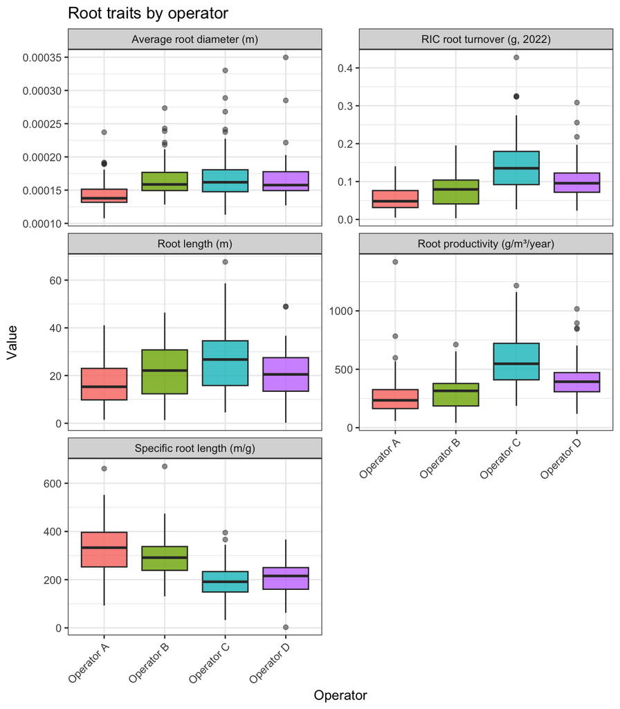

Figure 1: Root traits by operator.

```r
if (run_operator_analysis) {
  traits_for_plot <- intersect(
    c("dry_root_turnover_g", "root_length_m", "avg_root_diameter_m",
      "specific_root_length_m_per_g", "root_productivity_g_per_m3_per_year"),
    names(dat)
  )
  dat %>%
    select(siteID, blockID, plotID, treatment, operator_label, any_of(traits_for_plot)) %>%
    pivot_longer(any_of(traits_for_plot), names_to = "trait", values_to = "value") %>%
    filter(!is.na(value)) %>%
    mutate(trait_label = if_else(trait %in% names(TRAIT_LABELS), unname(TRAIT_LABELS[trait]), trait)) %>%
    ggplot(aes(x = operator_label, y = value, fill = operator_label)) +
    geom_boxplot(alpha = 0.8, outlier.alpha = 0.5) +
    facet_wrap(vars(trait_label), scales = "free_y", ncol = 2) +
    theme_bw() +
    theme(legend.position = "none", axis.text.x = element_text(angle = 45, hjust = 1)) +
    labs(title = "Root traits by operator", x = "Operator", y = "Value")
}
```

**RIC root turnover (`dry_root_turnover_g`) by treatment and operator.** Operators differ substantially because different people processed cores in the lab.

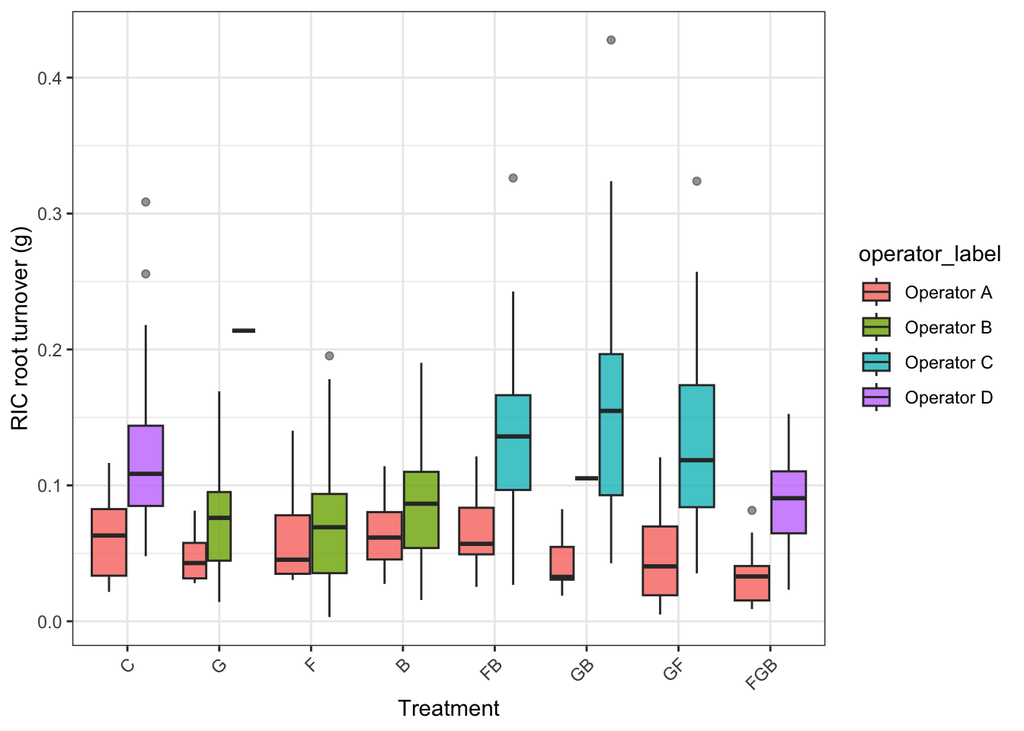

Figure 2: RIC root turnover by treatment and operator.

```r
if (run_operator_analysis) {
  dat %>%
    filter(!is.na(dry_root_turnover_g)) %>%
    ggplot(aes(x = treatment, y = dry_root_turnover_g, fill = operator_label)) +
    geom_boxplot(position = position_dodge(0.8), alpha = 0.8, outlier.alpha = 0.5) +
    theme_bw() +
    theme(axis.text.x = element_text(angle = 45, hjust = 1)) +
    labs(x = "Treatment", y = "RIC root turnover (g)")
}
```

**Average root diameter by treatment and operator.**

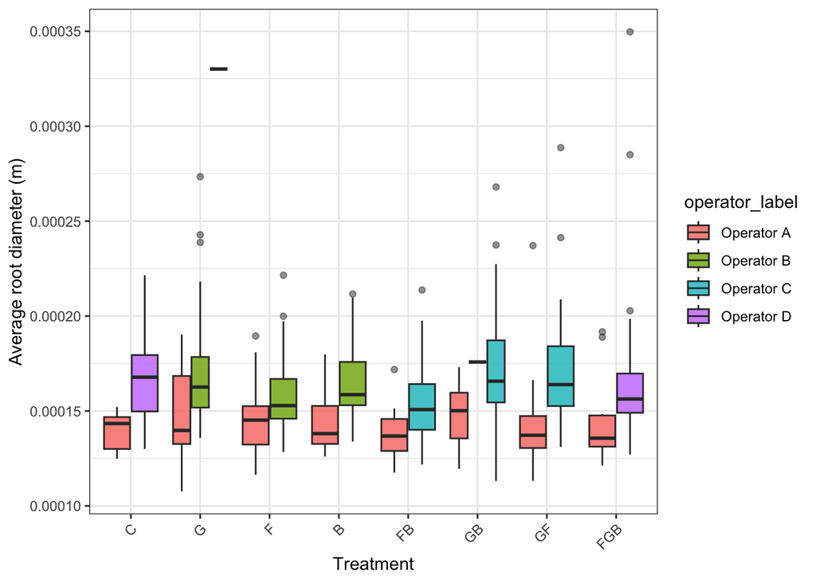

Figure 3: Average root diameter by treatment and operator.

```r
if (run_operator_analysis) {
  dat %>%
    filter(!is.na(avg_root_diameter_m)) %>%
    ggplot(aes(x = treatment, y = avg_root_diameter_m, fill = operator_label)) +
    geom_boxplot(position = position_dodge(0.8), alpha = 0.8, outlier.alpha = 0.5) +
    theme_bw() +
    theme(axis.text.x = element_text(angle = 45, hjust = 1)) +
    labs(x = "Treatment", y = TRAIT_LABELS["avg_root_diameter_m"])
}
```

**RIC root turnover by site and operator.** Similarly, large operator differences. The differences between sites are less visible.

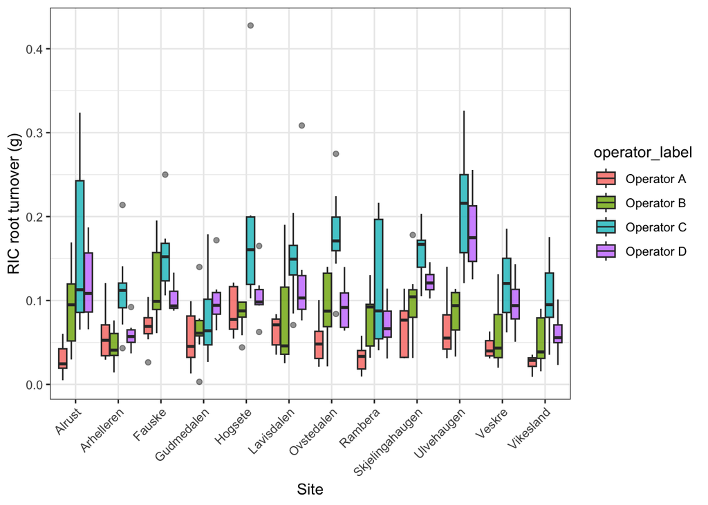

Figure 4: RIC root turnover by site and operator.

```r
if (run_operator_analysis) {
  dat %>%
    filter(!is.na(dry_root_turnover_g)) %>%
    ggplot(aes(x = siteID, y = dry_root_turnover_g, fill = operator_label)) +
    geom_boxplot(position = position_dodge(0.8), alpha = 0.8, outlier.alpha = 0.5) +
    theme_bw() +
    theme(axis.text.x = element_text(angle = 45, hjust = 1)) +
    labs(x = "Site", y = "RIC root turnover (g)")
}
```

### Correction: raw vs corrected

We apply the subset-based correction with a **treatment × operator interaction**: for each operator, the offset is estimated from shared treatments with the reference and can differ by treatment. Corrected = raw − treatment-specific offset. The plot below compares raw vs corrected RIC root turnover. Points on the dashed line would be unchanged; systematic shifts off the line show the correction.

```r
if (run_operator_analysis) {
  source("R/functions/correct_operator_bias.R")
  if (exists("root_traits_corrected")) {
    dat_corrected <- root_traits_corrected %>%
      filter(!is.na(operator)) %>%
      mutate(
        operator_label = factor(
          operator_display(operator),
          levels = levels(dat$operator_label)
        )
      )
  } else {
    dat_corrected <- apply_operator_correction(
      dat,
      trait_names = intersect(RIC_TRAIT_COLS, names(dat)),
      reference_operator = ref_operator,
      operator_model = "interaction"
    ) %>%
      mutate(
        operator_label = factor(
          operator_display(operator),
          levels = levels(dat$operator_label)
        )
      )
  }
  apply_operator_correction_local <- function(data, trait_names, reference_operator = NULL) {
    apply_operator_correction(
      data,
      trait_names = intersect(RIC_TRAIT_COLS, trait_names),
      reference_operator = if (is.null(reference_operator)) ref_operator else reference_operator,
      operator_model = "interaction"
    )
  }
}
```

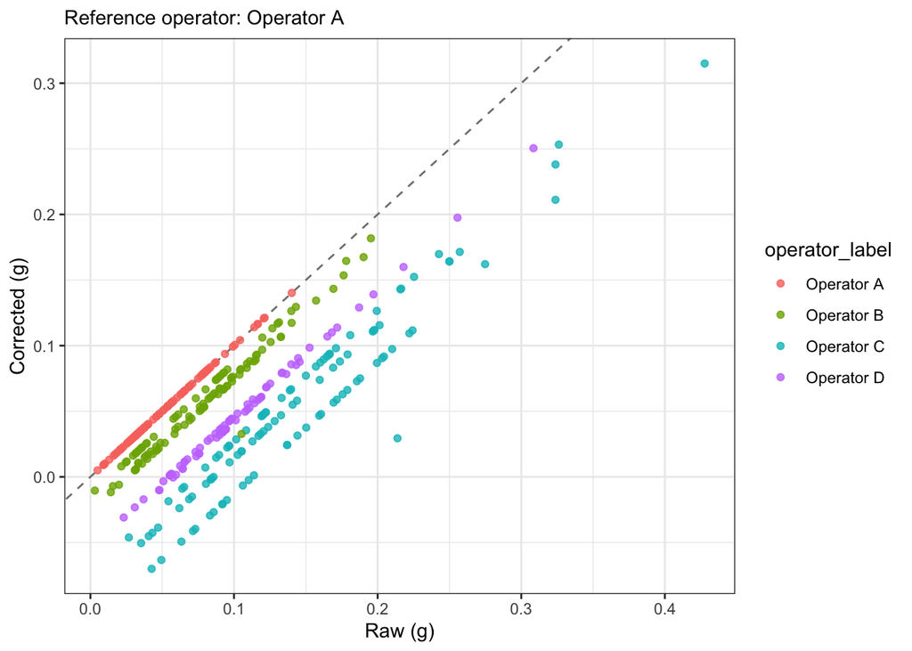

Figure 5: Raw vs operator-corrected RIC root turnover. Corrected to reference operator.

```r
if (run_operator_analysis && "dry_root_turnover_g_corrected" %in% names(dat_corrected)) {
  dat_corrected %>%
    filter(!is.na(dry_root_turnover_g)) %>%
    ggplot(aes(x = dry_root_turnover_g, y = dry_root_turnover_g_corrected, colour = operator_label)) +
    geom_abline(slope = 1, intercept = 0, linetype = 2, colour = "gray50") +
    geom_point(alpha = 0.8) +
    theme_bw() +
    labs(
      subtitle = "Reference operator: Operator A",
      x = "Raw (g)", y = "Corrected (g)"
    )
}
```

### Uncorrected vs corrected: treatment on x-axis

For RIC root turnover we compare uncorrected values to values corrected to the reference operator (Operator A). Below, **treatment is on the x-axis** and RIC root turnover on the y-axis. Each panel shows one correction type (Uncorrected or Corrected to Operator A); within each panel, points/boxes are coloured by the operator who measured. If the correction reduces operator bias, the spread between operators within each treatment should be smaller in the corrected panel than in the uncorrected panel.

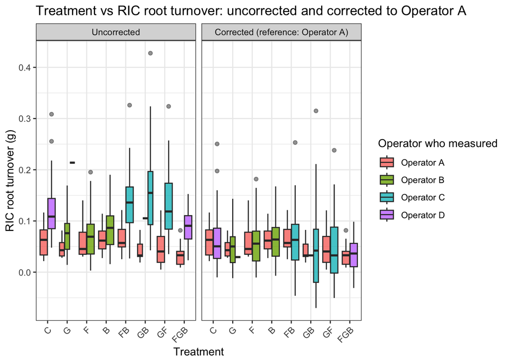

Figure 6: RIC root turnover by treatment: uncorrected and corrected to Operator A. Colour = operator who measured.

```r
if (run_operator_analysis) {
  trait_one <- "dry_root_turnover_g"
  ref_label <- operator_display(ref_operator)
  # Uncorrected
  long_correction <- dat %>%
    filter(!is.na(.data[[trait_one]])) %>%
    transmute(
      siteID, treatment, operator_label,
      value = .data[[trait_one]],
      correction_type = "Uncorrected"
    )
  # Corrected to reference operator
  d_corr <- apply_operator_correction_local(dat, trait_one, reference_operator = ref_operator)
  idx <- which(!is.na(dat[[trait_one]]))
  long_correction <- bind_rows(
    long_correction,
    d_corr %>%
      slice(idx) %>%
      transmute(
        siteID, treatment,
        operator_label = operator_display(operator),
        value = .data[[paste0(trait_one, "_corrected")]],
        correction_type = paste0("Corrected (reference: ", ref_label, ")")
      )
  )
  correction_order <- c("Uncorrected", paste0("Corrected (reference: ", ref_label, ")"))
  long_correction <- long_correction %>%
    mutate(
      operator_label = factor(operator_label, levels = levels(dat$operator_label)),
      correction_type = factor(correction_type, levels = correction_order)
    )
  ggplot(long_correction, aes(x = treatment, y = value, fill = operator_label)) +
    geom_boxplot(position = position_dodge(0.8), alpha = 0.8, outlier.alpha = 0.5) +
    facet_wrap(vars(correction_type), ncol = 2) +
    theme_bw() +
    theme(axis.text.x = element_text(angle = 45, hjust = 1)) +
    labs(
      x = "Treatment",
      y = "RIC root turnover (g)",
      fill = "Operator who measured",
      title = "Treatment vs RIC root turnover: uncorrected and corrected to Operator A"
    )
}
```

## Effect of correction on treatment analysis

We fit the mixed model **RIC root turnover ~ treatment + (1|siteID)** once with raw values and once with operator-corrected values (reference: Operator A), to see how the correction affects the treatment effect and model statistics.

```r
if (run_operator_analysis && exists("apply_operator_correction_local")) {
  suppressPackageStartupMessages({
    library(lme4)
    library(lmerTest)
    library(emmeans)
  })
  ref_operator_analysis <- ref_operator
  dat_corrected_ref <- apply_operator_correction_local(dat, "dry_root_turnover_g", reference_operator = ref_operator_analysis)
  d_model <- dat_corrected_ref %>%
    filter(!is.na(dry_root_turnover_g), !is.na(dry_root_turnover_g_corrected))
  m_raw       <- lmer(dry_root_turnover_g ~ treatment + (1|siteID), data = d_model)
  m_corrected <- lmer(dry_root_turnover_g_corrected ~ treatment + (1|siteID), data = d_model)
}
```

### Model: raw RIC root turnover ~ treatment + (1|siteID)

```r
if (run_operator_analysis && exists("m_raw")) {
  fix_raw <- as.data.frame(coef(summary(m_raw)))
  fix_raw <- fix_raw %>% mutate(term = rownames(fix_raw), .before = 1)
  emm_raw <- as.data.frame(emmeans::emmeans(m_raw, ~ treatment))
  emm_raw <- emm_raw %>% select(treatment, emmean, SE, df, lower.CL, upper.CL)
  re_raw <- as.data.frame(VarCorr(m_raw)) %>% select(grp, var1, vcov, sdcor)
  knitr::kable(fix_raw, digits = 4, caption = "Fixed effects: raw RIC root turnover", col.names = c("Term", "Estimate", "Std. Error", "df", "t value", "Pr(>|t|)"))
  #knitr::kable(emm_raw, digits = 4, caption = "Estimated marginal means by treatment: raw model")
}
```

```
Cannot use mode = "kenward-roger" because *pbkrtest* package is not installed
```

Table 7: Fixed effects: raw RIC root turnover

|  | Term | Estimate | Std. Error | df | t value | Pr(>\|t\|) |
| --- | --- | --- | --- | --- | --- | --- |
| (Intercept) | (Intercept) | 0.1066 | 0.0099 | 51.6501 | 10.8160 | 0.0000 |
| treatmentG | treatmentG | -0.0368 | 0.0110 | 362.0253 | -3.3561 | 0.0009 |
| treatmentF | treatmentF | -0.0346 | 0.0110 | 362.0253 | -3.1557 | 0.0017 |
| treatmentB | treatmentB | -0.0244 | 0.0110 | 362.0717 | -2.2151 | 0.0274 |
| treatmentFB | treatmentFB | 0.0155 | 0.0110 | 362.0253 | 1.4080 | 0.1600 |
| treatmentGB | treatmentGB | 0.0205 | 0.0110 | 362.0717 | 1.8539 | 0.0646 |
| treatmentGF | treatmentGF | 0.0064 | 0.0110 | 362.0253 | 0.5875 | 0.5572 |
| treatmentFGB | treatmentFGB | -0.0316 | 0.0110 | 362.0253 | -2.8772 | 0.0042 |

### Model: corrected RIC root turnover ~ treatment + (1|siteID)

Corrected values use Operator A as the reference operator.

```r
if (run_operator_analysis && exists("m_corrected")) {
  fix_corr <- as.data.frame(coef(summary(m_corrected)))
  fix_corr <- fix_corr %>% mutate(term = rownames(fix_corr), .before = 1)
  emm_corr <- as.data.frame(emmeans::emmeans(m_corrected, ~ treatment))
  emm_corr <- emm_corr %>% select(treatment, emmean, SE, df, lower.CL, upper.CL)
  re_corr <- as.data.frame(VarCorr(m_corrected)) %>% select(grp, var1, vcov, sdcor)
  knitr::kable(fix_corr, digits = 4, caption = "Fixed effects: corrected RIC root turnover (reference: Operator A)", col.names = c("Term", "Estimate", "Std. Error", "df", "t value", "Pr(>|t|)"))
  #knitr::kable(emm_corr, digits = 4, caption = "Estimated marginal means by treatment: corrected model")
}
```

```
Cannot use mode = "kenward-roger" because *pbkrtest* package is not installed
```

Table 8: Fixed effects: corrected RIC root turnover (reference: Operator A)

|  | Term | Estimate | Std. Error | df | t value | Pr(>\|t\|) |
| --- | --- | --- | --- | --- | --- | --- |
| (Intercept) | (Intercept) | 0.0622 | 0.0091 | 35.2429 | 6.8326 | 0.0000 |
| treatmentG | treatmentG | -0.0151 | 0.0091 | 362.0164 | -1.6543 | 0.0989 |
| treatmentF | treatmentF | -0.0003 | 0.0091 | 362.0164 | -0.0373 | 0.9703 |
| treatmentB | treatmentB | 0.0031 | 0.0092 | 362.0474 | 0.3397 | 0.7342 |
| treatmentFB | treatmentFB | 0.0052 | 0.0091 | 362.0164 | 0.5678 | 0.5705 |
| treatmentGB | treatmentGB | -0.0181 | 0.0092 | 362.0474 | -1.9711 | 0.0495 |
| treatmentGF | treatmentGF | -0.0152 | 0.0091 | 362.0164 | -1.6662 | 0.0965 |
| treatmentFGB | treatmentFGB | -0.0277 | 0.0091 | 362.0164 | -3.0333 | 0.0026 |